# Women’s Clothing E-Commerce Reviews Analysis

Irmak Özveren - Halit Kaan Kesgin - Fatemeh Shirazi

# 1 Introduction

This report analyzes the **Women’s Clothing E-Commerce Reviews** dataset using text mining, sentiment analysis, latent semantic analysis, mixture of unigrams, LDA, and clustering evaluation metrics.

Online clothing reviews contain customer opinions about fit, size, fabric, comfort, color, and overall satisfaction. Analyzing these reviews helps identify dominant product-related concerns and understand how review language relates to recommendation behavior and product departments.

The objective of this project is to apply text mining methods to women’s clothing e-commerce reviews in order to detect major themes, analyze sentiment patterns, and compare topic/clustering models.

The main goals are:

- to clean and preprocess review text,
- to explore frequent words and sentiment patterns,
- to extract latent semantic structures,
- to compare clustering performance between MOU and LDA,
- to evaluate model alignment with `Department.Name` labels.

# 2 Dataset Description

The dataset used in this project is the Women’s Clothing E-Commerce Reviews dataset. Each document corresponds to one customer review written for a women’s clothing product. The main text variable is Review.Text. The text type is online product reviews.

The available labels used for evaluation are Department.Name and Recommended.IND. Department.Name was used as the external label for clustering evaluation, while Recommended.IND was used to compare sentiment categories with recommendation status.

```r
# Packages
library(tm)
library(lsa)
library(topicmodels)
library(skmeans)
library(mclust)
library(wordcloud)
library(RColorBrewer)
library(cluster)
library(tidyverse)
library(tidytext)
library(deepMOU)
```

```r
# Data Loading
clothing_data <- read.csv(
  "Womens Clothing E-Commerce Reviews.csv",
  stringsAsFactors = FALSE
)

# Remove rows with missing or empty review text
df_analysis <- clothing_data %>%
  filter(!is.na(Review.Text) & Review.Text != "")

n_docs <- nrow(df_analysis)
n_docs
```

```
## [1] 22641
```

# 3 Data Preprocessing

## 3.1 Text Cleaning and Corpus Construction

The raw review text was converted into a corpus. The following cleaning steps were applied: lowercasing, punctuation removal, number removal, standard English stopword removal, SMART stopword removal, whitespace stripping, and domain-specific stopword removal.

Stemming was applied using the English stemming algorithm. After stemming, additional stemmed domain-specific stopwords were removed.

```r
corpus <- VCorpus(VectorSource(df_analysis$Review.Text))

corpus <- corpus %>%
  tm_map(content_transformer(tolower)) %>%
  tm_map(removePunctuation) %>%
  tm_map(removeNumbers) %>%
  tm_map(removeWords, stopwords("english")) %>%
  tm_map(stripWhitespace) %>%
  tm_map(removeWords, stopwords("SMART"))

# Context-specific stopwords
fashion_stopwords <- c(
  "review", "order", "purchas", "store", "retail", "online",
  "make", "made", "work", "look", "want", "time", "day", "person"
)

corpus <- tm_map(corpus, removeWords, fashion_stopwords)

# Stemming
corpus <- tm_map(corpus, stemDocument, language = "english")

fashion_stopwords_stemmed <- c(
  "review", "order", "purchas", "store", "retail", "onlin",
  "make", "made", "work", "look", "want", "time", "day", "person"
)

corpus <- tm_map(corpus, removeWords, fashion_stopwords_stemmed)
```

## 3.2 Document-Term Matrix and Removing Rare Words

A Document-Term Matrix was constructed where rows represent reviews and columns represent terms. Rare words occurring once or less were removed.

```r
# Rows = documents, columns = words
dtm <- DocumentTermMatrix(corpus)
dtm_matrix <- as.matrix(dtm)

# Word counts across columns
word_counts <- colSums(dtm_matrix)
word_freqs <- sort(word_counts, decreasing = TRUE)

head(word_freqs, 10)
```

```
##   dress    love     fit    size     top    wear   color   great perfect  fabric
##   12062   11351   11315   10603    8261    8047    7191    6084    5225    4852
```

```r
rare_words <- names(word_counts[word_counts <= 1])
dtm_clean_mat <- dtm_matrix[, !(colnames(dtm_matrix) %in% rare_words)]

# Vocabulary size p and document count n
p_vocab <- ncol(dtm_clean_mat)
n_docs <- nrow(dtm_clean_mat)

cat("Vocabulary size p:", p_vocab, "\n")
```

```
## Vocabulary size p: 5818
```

```r
cat("Number of Documents n:", n_docs, "\n")
```

```
## Number of Documents n: 22641
```

After removing missing and empty review texts, the final dataset contains 22,641 reviews.

After preprocessing and removing rare words, the final vocabulary size is 5,818 terms.

# 4 Exploratory Text Analysis

## 4.1 Word Frequency Analysis

```r
word_freqs <- sort(colSums(dtm_clean_mat), decreasing = TRUE)
df_freq <- data.frame(
  word = names(word_freqs),
  freq = word_freqs
)

head(df_freq, 20)
```

```
##            word  freq
## dress     dress 12062
## love       love 11351
## fit         fit 11315
## size       size 10603
## top         top  8261
## wear       wear  8047
## color     color  7191
## great     great  6084
## perfect perfect  5225
## fabric   fabric  4852
## small     small  4574
## nice       nice  3800
## flatter flatter  3657
## beauti   beauti  3465
## soft       soft  3375
## comfort comfort  3277
## back       back  3180
## cute       cute  3024
## bought   bought  2981
## bit         bit  2874
```

The most frequent terms were dress, love, fit, size, top, wear, color, great, perfect, and fabric. These terms suggest that the dominant themes are product type, fit, sizing, appearance, color, fabric quality, and customer satisfaction.

## 4.2 Word Cloud

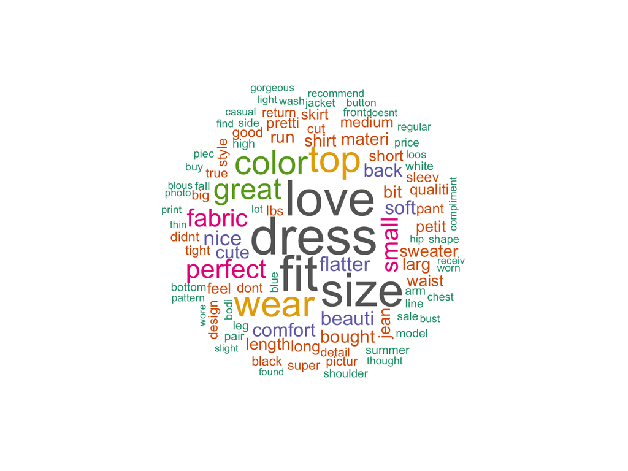

```r
wordcloud(
  words = df_freq$word,
  freq = df_freq$freq,
  min.freq = 3,
  max.words = 100,
  random.order = FALSE,
  colors = brewer.pal(8, "Dark2")
)
```

# 5 Methodology

## 5.1 Sentiment Analysis

Sentiment analysis was performed using the Bing lexicon. Each review was tokenized into words, stopwords were removed, and remaining words were matched with positive or negative sentiment labels.

```r
reviews_df <- tibble(
  line = 1:nrow(df_analysis),
  text = df_analysis$Review.Text,
  Recommended = df_analysis$Recommended.IND
)

data("stop_words")
bing_sentiments <- get_sentiments("bing")

reviews_words_clean <- reviews_df %>%
  unnest_tokens(word, text) %>%
  anti_join(stop_words, by = "word")

reviews_sentiment <- reviews_words_clean %>%
  inner_join(bing_sentiments, by = "word")
```

### 5.1.1 Sentiment Score Calculation

For each review, the sentiment score was computed as: sentiment score = number of positive words − number of negative words

Reviews with positive scores were classified as Positive, negative scores as Negative, and zero scores as Neutral.

```r
review_scores <- reviews_sentiment %>%
  count(line, sentiment) %>%
  pivot_wider(
    names_from = sentiment,
    values_from = n,
    values_fill = 0
  ) %>%
  mutate(sentiment_score = positive - negative)

final_sentiment <- reviews_df %>%
  left_join(review_scores, by = "line") %>%
  mutate(sentiment_score = ifelse(is.na(sentiment_score), 0, sentiment_score)) %>%
  mutate(
    sentiment_category = case_when(
      sentiment_score > 0 ~ "Positive",
      sentiment_score < 0 ~ "Negative",
      TRUE ~ "Neutral"
    )
  )

head(final_sentiment)
```

```
## # A tibble: 6 × 7
##    line text    Recommended positive negative sentiment_score sentiment_category
##   <int> <chr>         <int>    <int>    <int>           <dbl> <chr>
## 1     1 "Absol…           1        3        0               3 Positive
## 2     2 "Love …           1        4        0               4 Positive
## 3     3 "I had…           0        3        3               0 Neutral
## 4     4 "I lov…           1        5        1               4 Positive
## 5     5 "This …           1        4        0               4 Positive
## 6     6 "I lov…           0        3        2               1 Positive
```

### 5.1.2 Distribution of Sentiment Scores

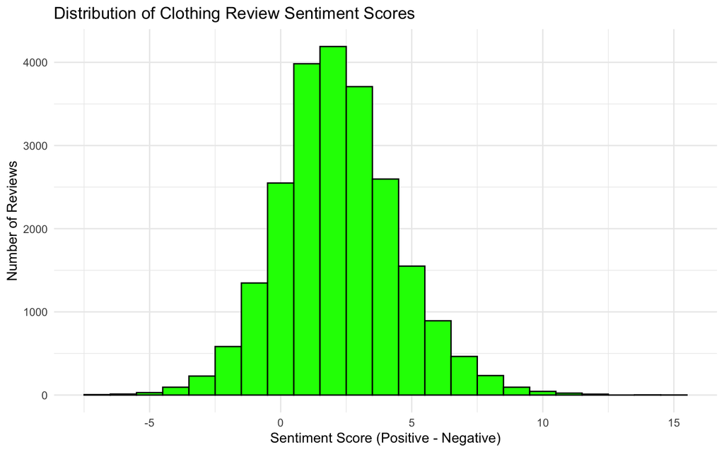

```r
ggplot(final_sentiment, aes(x = sentiment_score)) +
  geom_histogram(binwidth = 1, fill = "green", color = "black") +
  theme_minimal() +
  labs(
    title = "Distribution of Clothing Review Sentiment Scores",
    x = "Sentiment Score (Positive - Negative)",
    y = "Number of Reviews"
  )
```

### 5.1.3 Top Sentiment-Contributing Words

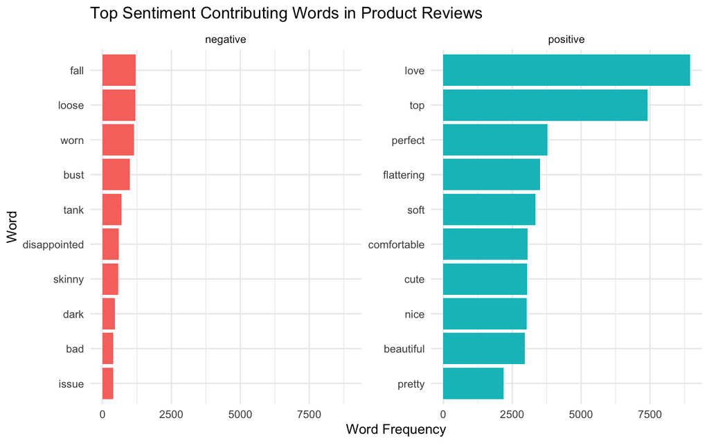

```r
reviews_words_clean %>%
  inner_join(bing_sentiments, by = "word") %>%
  count(word, sentiment, sort = TRUE) %>%
  group_by(sentiment) %>%
  slice_max(n, n = 10) %>%
  ungroup() %>%
  mutate(word = reorder(word, n)) %>%
  ggplot(aes(x = word, y = n, fill = sentiment)) +
  geom_col(show.legend = FALSE) +
  facet_wrap(~ sentiment, scales = "free_y") +
  coord_flip() +
  labs(
    title = "Top Sentiment Contributing Words in Product Reviews",
    y = "Word Frequency",
    x = "Word"
  ) +
  theme_minimal()
```

### 5.1.4 Sentiment Categories by Recommendation Status

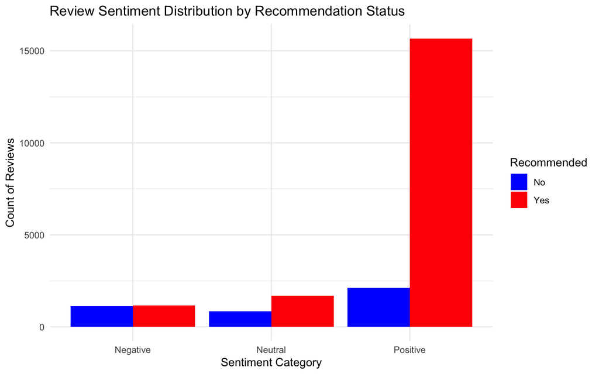

```r
ggplot(final_sentiment, aes(x = sentiment_category, fill = factor(Recommended))) +
  geom_bar(position = "dodge") +
  scale_fill_manual(
    values = c("0" = "blue", "1" = "red"),
    name = "Recommended",
    labels = c("No", "Yes")
  ) +
  theme_minimal() +
  labs(
    title = "Review Sentiment Distribution by Recommendation Status",
    x = "Sentiment Category",
    y = "Count of Reviews"
  )
```

## 5.2 Latent Semantic Analysis (LSA)

LSA was applied using Singular Value Decomposition on the cleaned document-term matrix. SVD decomposes the matrix into latent components that summarize major patterns of word usage. The singular values and explained variance were examined to understand how much information each component captured.

```r
# Singular Value Decomposition on document-term matrix
svd_out <- svd(dtm_clean_mat)

dim(dtm_clean_mat)
```

```
## [1] 22641  5818
```

```r
length(svd_out$d)
```

```
## [1] 5818
```

### 5.2.1 SVD Component Importance

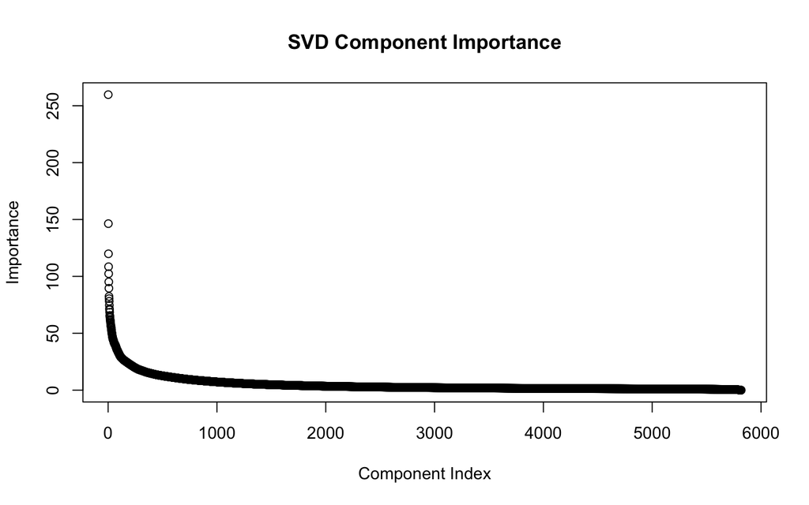

```r
plot(
  svd_out$d,
  main = "SVD Component Importance",
  ylab = "Importance",
  xlab = "Component Index"
)
```

### 5.2.2 Explained Variance

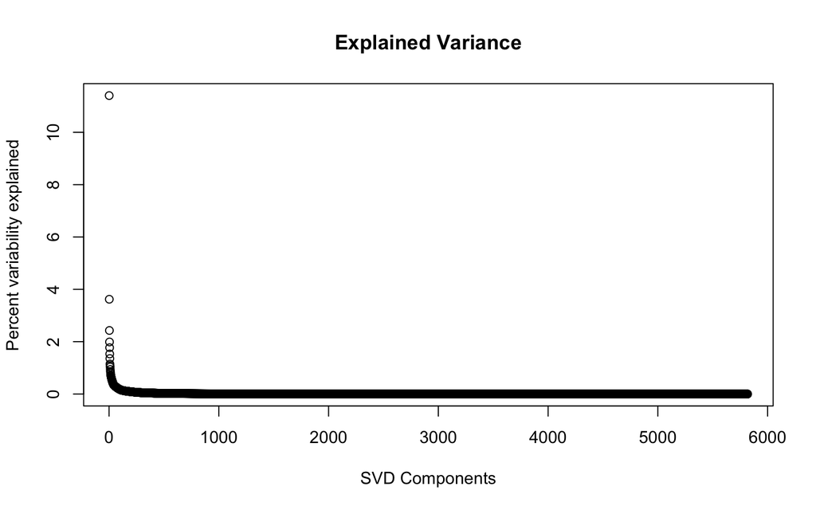

```r
plot(
  svd_out$d^2 / sum(svd_out$d^2) * 100,
  ylab = "Percent variability explained",
  xlab = "SVD Components",
  main = "Explained Variance"
)
```

### 5.2.3 Low-Rank Approximation

```r
td_appr <- svd_out$u[, 1:2, drop = FALSE] %*%
  diag(svd_out$d[1:2]) %*%
  t(svd_out$v[, 1:2, drop = FALSE])

rownames(td_appr) <- rownames(dtm_clean_mat)
colnames(td_appr) <- colnames(dtm_clean_mat)

dim(td_appr)
```

```
## [1] 22641  5818
```

The sharp decline in singular values indicates that the first few components capture much of the important structure in the review data. Therefore, SVD is useful for dimensionality reduction and for preparing text data for clustering or further semantic analysis.

### 5.2.4 Suggested Number of Topics

The value of $q$ represents the number of latent dimensions needed to explain at least 70% of the total variance in the document-term matrix. This helps reduce dimensionality while still preserving the main semantic structure of the reviews.

In LSA, these latent dimensions capture underlying semantic patterns between words and documents rather than explicit topics. Using explained variance helps balance information retention and interpretability.

```r
q <- which((cumsum(svd_out$d^2) / sum(svd_out$d^2)) > 0.70)[1]
q
```

```
## [1] 185
```

### 5.2.5 Top Words for Latent Topics

```r
A <- abs(t(svd_out$v[, 1:q]))
colnames(A) <- colnames(dtm_clean_mat)

get_top_words <- function(topic_index, n = 5) {
  index <- order(A[topic_index, ], decreasing = TRUE)
  colnames(dtm_clean_mat)[index[1:n]]
}

for (i in 1:5) {
  cat("\nTop 5 words for Latent Topic", i, ":", get_top_words(i, 5))
}
```

```
##
## Top 5 words for Latent Topic 1 : dress fit size love top
## Top 5 words for Latent Topic 2 : dress top size fit love
## Top 5 words for Latent Topic 3 : size love top fit color
## Top 5 words for Latent Topic 4 : top love dress fit color
## Top 5 words for Latent Topic 5 : fit love size perfect great
```

## 5.3 Mixture of Unigrams (MOU) Estimation

The Mixture of Unigrams model was used as a clustering approach. It assumes that each document belongs to one latent cluster and that words are generated from a cluster-specific multinomial distribution. Models with different numbers of clusters were compared using AIC.

```r
# Since the dataset is large, only k = 2 and k = 3 are checked.
fit_mou2 <- mou_EM(dtm_clean_mat, k = 2, seed = 123)
fit_mou3 <- mou_EM(dtm_clean_mat, k = 3, seed = 123)

mou_k <- c(fit_mou2$k, fit_mou3$k)
mou_aic <- c(fit_mou2$AIC, fit_mou3$AIC)

cat("MOU AIC Scores (k = 2 vs k = 3):", mou_aic, "\n")
```

```
## MOU AIC Scores (k = 2 vs k = 3): 6043068 6027677
```

```r
cat("Best MOU cluster choice based on AIC:", mou_k[which.min(mou_aic)], "clusters.\n")
```

```
## Best MOU cluster choice based on AIC: 3 clusters.
```

```r
best_mou <- if (fit_mou2$AIC < fit_mou3$AIC) fit_mou2 else fit_mou3
mou_clusters <- best_mou$clusters
```

### 5.3.1 MOU Heatmap

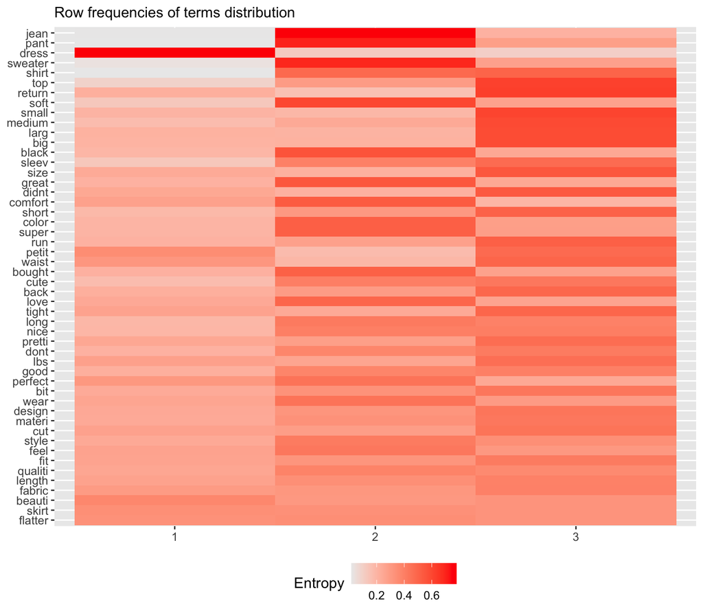

```r
heatmap_words(
  x = dtm_clean_mat,
  clusters = mou_clusters
)
```

### 5.3.2 Word Frequency Plot by MOU Cluster

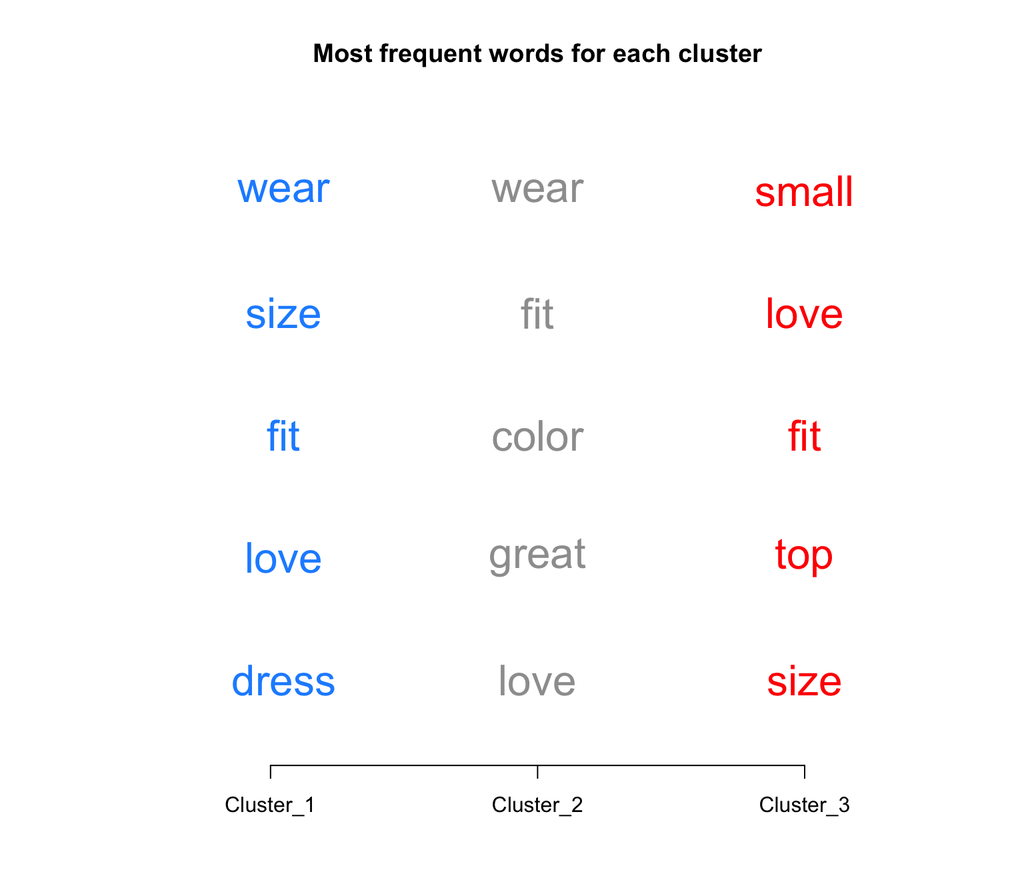

```r
words_freq_plot(
  dtm_clean_mat,
  clusters = mou_clusters
)
```

## 5.4 Latent Dirichlet Allocation (LDA)

LDA was used for probabilistic topic modeling. Unlike Mixture of Unigrams, LDA represents each document as a mixture of topics. A three-topic LDA model was fitted, and the top words from each topic were used for interpretation.

```r
dtm_clean <- dtm[, !(Terms(dtm) %in% rare_words)]

# k = 3 was selected to obtain interpretable and stable latent semantic topics.
fit_lda <- LDA(
  dtm_clean,
  k = 3,
  method = "VEM",
  control = list(seed = 123)
)

# Probability of each document belonging to each topic
theta_fit <- fit_lda@gamma

# Top 10 words per topic
terms(fit_lda, 10)
```

```
##       Topic 1  Topic 2   Topic 3
##  [1,] "top"    "fit"     "dress"
##  [2,] "love"   "dress"   "color"
##  [3,] "size"   "great"   "love"
##  [4,] "dress"  "perfect" "fit"
##  [5,] "fabric" "flatter" "great"
##  [6,] "wear"   "cute"    "size"
##  [7,] "color"  "wear"    "comfort"
##  [8,] "nice"   "soft"    "small"
##  [9,] "fit"    "small"   "wear"
## [10,] "materi" "beauti"  "perfect"
```

```r
# Most likely topic per document
doc_topics <- topics(fit_lda)

table(doc_topics)
```

```
## doc_topics
##    1    2    3
## 7497 7725 7419
```

### 5.4.1 LDA Topic Distribution

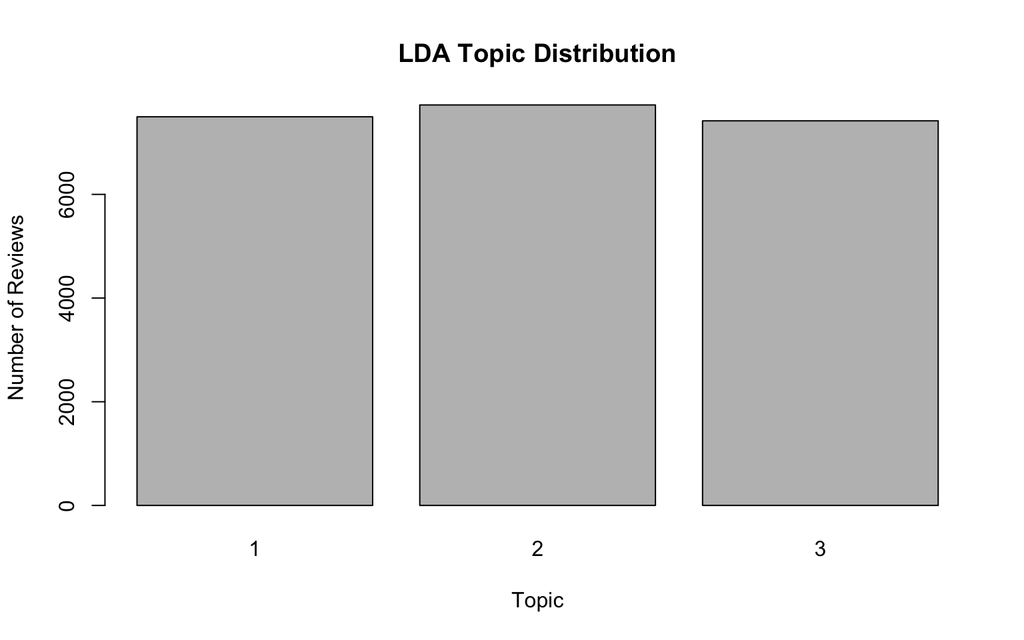

```r
barplot(
  table(doc_topics),
  main = "LDA Topic Distribution",
  xlab = "Topic",
  ylab = "Number of Reviews"
)
```

### 5.4.2 LDA Top Words

```r
lda_terms <- terms(fit_lda, 10)

topic1_df <- data.frame(
  word = lda_terms[, 1],
  rank = 10:1
)

topic2_df <- data.frame(
  word = lda_terms[, 2],
  rank = 10:1
)

topic3_df <- data.frame(
  word = lda_terms[, 3],
  rank = 10:1
)
```

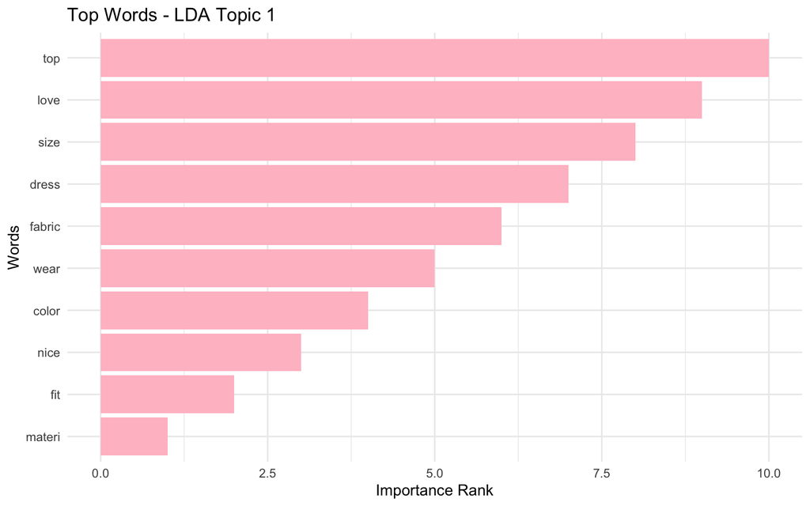

```r
ggplot(topic1_df, aes(x = reorder(word, rank), y = rank)) +
  geom_col(fill = "pink") +
  coord_flip() +
  theme_minimal() +
  labs(
    title = "Top Words - LDA Topic 1",
    x = "Words",
    y = "Importance Rank"
  )
```

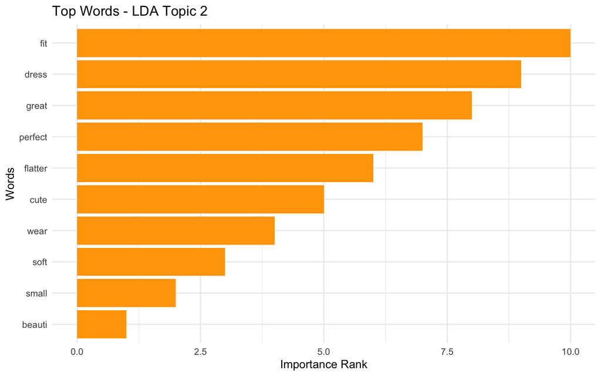

```r
ggplot(topic2_df, aes(x = reorder(word, rank), y = rank)) +
  geom_col(fill = "orange") +
  coord_flip() +
  theme_minimal() +
  labs(
    title = "Top Words - LDA Topic 2",
    x = "Words",
    y = "Importance Rank"
  )
```

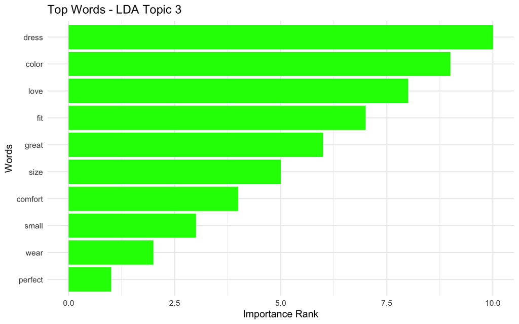

```r
ggplot(topic3_df, aes(x = reorder(word, rank), y = rank)) +
  geom_col(fill = "green") +
  coord_flip() +
  theme_minimal() +
  labs(
    title = "Top Words - LDA Topic 3",
    x = "Words",
    y = "Importance Rank"
  )
```

## 5.5 Topic Interpretation

### 5.5.1 LDA

Topic 1: top, love, size, dress, fabric, wear, color, nice, fit, material This topic appears related to general clothing quality, especially tops, fabric, fit, and material.

Topic 2: fit, dress, great, perfect, flatter, cute, wear, soft, small, beautiful This topic reflects positive evaluations of fit, attractiveness, comfort, and flattering design.

Topic 3: dress, color, love, fit, great, size, comfort, small, wear, perfect This topic is mainly related to dresses, color, sizing, comfort, and positive satisfaction.

### 5.5.2 MOU

Cluster 1 is strongly associated with Dresses. Cluster 2 is mainly associated with Tops, but also includes Bottoms and Intimate items. Cluster 3 is also strongly associated with Tops, with additional Dresses and Intimate reviews.

Therefore, MOU captures product-department structure better than LDA, but Tops are split across two clusters, suggesting overlap in vocabulary across product categories.

# 6 Model Selection

For MOU, models with k = 2 and k = 3 clusters were compared using AIC. Since lower AIC indicates a better model, k = 3 was selected for MOU.

For LDA, k = 3 was selected to obtain interpretable and stable topics and to allow comparison with the three-cluster MOU model.

```r
# Evaluation Metrics with `Department.Name` as Label
cl_true <- df_analysis$Department.Name
```

## 6.1 MOU Evaluation

```r
# MOU clusters vs Department.Name labels
table(mou_clusters, cl_true)
```

```
##             cl_true
## mou_clusters      Bottoms Dresses Intimate Jackets Tops Trend
##            1    0     447    4425      177      44  369    41
##            2   12    2003     671      796     623 4974    30
##            3    1    1212    1049      680     335 4705    47
```

```r
# Adjusted Rand Index
ari_mou <- adjustedRandIndex(mou_clusters, cl_true)
cat("MOU Adjusted Rand Index:", round(ari_mou, 4), "\n")
```

```
## MOU Adjusted Rand Index: 0.1899
```

```r
# Accuracy
mou_table <- table(mou_clusters, cl_true)
mou_accuracy <- sum(apply(mou_table, 1, max)) / sum(mou_table)
cat("MOU Accuracy:", round(mou_accuracy, 4), "\n")
```

```
## MOU Accuracy: 0.6229
```

## 6.2 LDA Evaluation

```r
lda_clusters <- apply(theta_fit, 1, which.max)

# LDA topics vs Department.Name labels
table(lda_clusters, cl_true)
```

```
##             cl_true
## lda_clusters      Bottoms Dresses Intimate Jackets Tops Trend
##            1    7    1257    1740      566     188 3701    38
##            2    4    1220    2199      537     444 3279    42
##            3    2    1185    2206      550     370 3068    38
```

```r
# Adjusted Rand Index
ari_lda <- adjustedRandIndex(lda_clusters, cl_true)
cat("LDA Adjusted Rand Index:", round(ari_lda, 4), "\n")
```

```
## LDA Adjusted Rand Index: 0.0033
```

```r
# Accuracy
lda_table <- table(lda_clusters, cl_true)
lda_accuracy <- sum(apply(lda_table, 1, max)) / sum(lda_table)
cat("LDA Accuracy:", round(lda_accuracy, 4), "\n")
```

```
## LDA Accuracy: 0.4438
```

```r
model_comparison <- data.frame(
  Model = c("MOU", "LDA"),
  Clusters_or_Topics = c(length(unique(mou_clusters)), 3),
  ARI = c(round(ari_mou, 4), round(ari_lda, 4)),
  Accuracy = c(round(mou_accuracy, 4), round(lda_accuracy, 4))
)

model_comparison
```

```
##   Model Clusters_or_Topics    ARI Accuracy
## 1   MOU                  3 0.1899   0.6229
## 2   LDA                  3 0.0033   0.4438
```

## 6.3 ARI Comparison

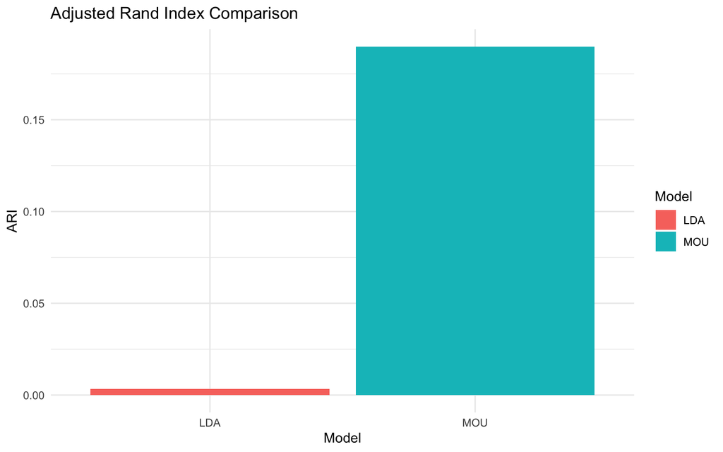

```r
ggplot(model_comparison, aes(x = Model, y = ARI, fill = Model)) +
  geom_col() +
  theme_minimal() +
  labs(
    title = "Adjusted Rand Index Comparison",
    x = "Model",
    y = "ARI"
  )
```

## 6.4 Accuracy Comparison

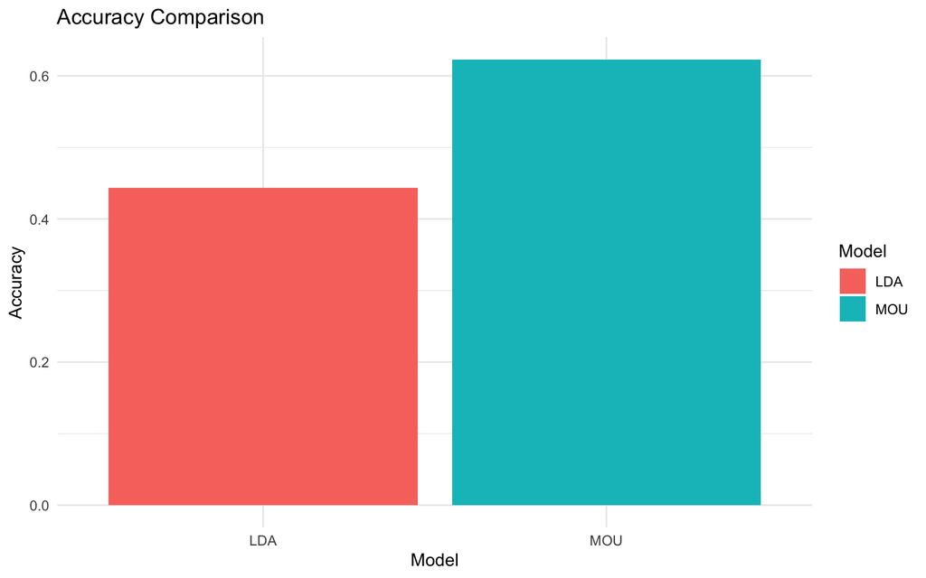

```r
ggplot(model_comparison, aes(x = Model, y = Accuracy, fill = Model)) +
  geom_col() +
  theme_minimal() +
  labs(
    title = "Accuracy Comparison",
    x = "Model",
    y = "Accuracy"
  )
```

Although LDA successfully extracted balanced latent semantic topics from the reviews, the discovered topic structure showed weak alignment with the department labels, resulting in an Adjusted Rand Index close to zero. This suggests that recommendation behavior and department membership are influenced by factors beyond latent semantic topics alone.

LSA was not directly compared with MOU and LDA because it serves a different purpose in this report. LSA is mainly a dimensionality reduction method based on SVD, while MOU and LDA are probabilistic models designed for clustering and topic modeling. Unlike MOU and LDA, LSA does not produce explicit document-topic or cluster assignments. In this project, LSA was mainly used for exploratory semantic analysis and dimensionality reduction.

## 6.5 Conclusion

MOU achieved better alignment with the `Department.Name` labels than LDA. After additional domain-specific stopword removal, MOU reached the highest ARI and accuracy among the fitted models. This suggests that MOU captured product-department structure more effectively.

LDA produced balanced and interpretable topic mixtures, but these topics showed weaker direct alignment with `Department.Name` labels when converted into hard clusters. Therefore, MOU was selected as the main clustering model, while LDA was used mainly for topic interpretation and LSA/SVD for dimensionality reduction.

# 7 Discussion

The analysis shows that customer reviews are dominated by product-related terms such as fit, size, dress, top, wear, color, fabric, and comfort. This suggests that customers mainly discuss practical product characteristics rather than abstract opinions.

Sentiment analysis indicates that many reviews contain positive words such as love, great, perfect, cute, and beautiful. This aligns with the recommendation variable because recommended products are expected to have more positive sentiment.

The topic models produced interpretable results, but their alignment with department labels differed. MOU achieved better external alignment than LDA, with higher ARI and accuracy. LDA produced balanced topics, but these topics were more semantic than department-specific.

Overall, the topics are meaningful, but department prediction from review text is difficult because different product departments share similar vocabulary, especially words such as fit, size, love, wear, and color.